# Wine Quality Analysis

Aritra Chatterjee

17 April 2018

## Introduction

The data set contains 13 features on wine quality for Red and White wines. The objective is to do exploratory data analysis.

The first part of the document contains the relationship between in the influencing variable on the quality of wine for both the category.

In second part, given the data for different feature, classification model had been built in order to classify wine in Red or White category. In order to acheive the result, the data set had been split into training and validation set. Confusion matrix had been drawn in order to show the accuracy rate of the model

Lets get started!

#### Setup the working directory and load necessary packages

## Read the dataset

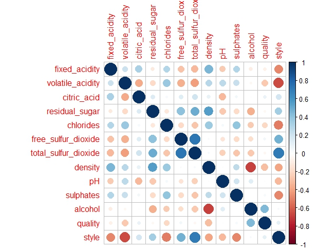

Corrplot

#### Top contributor in determing the quality of wine are

`"Alcohol"`,`"density"`,`"chlorides"` and `"volatile_acidity"`

### Unvariate Analysis

Let us see the relationship between the variables and the quality of the wine with the help of ggplot()

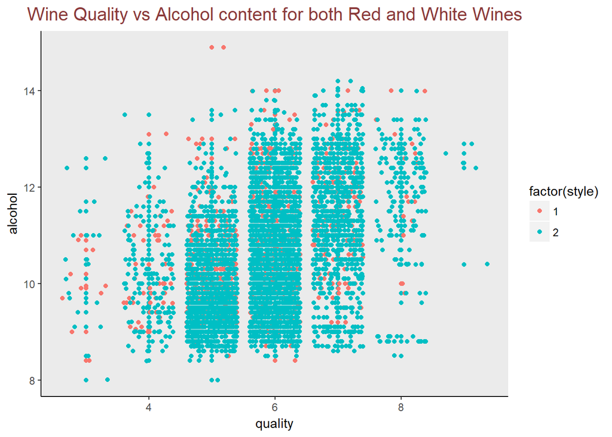

[figure not shown]

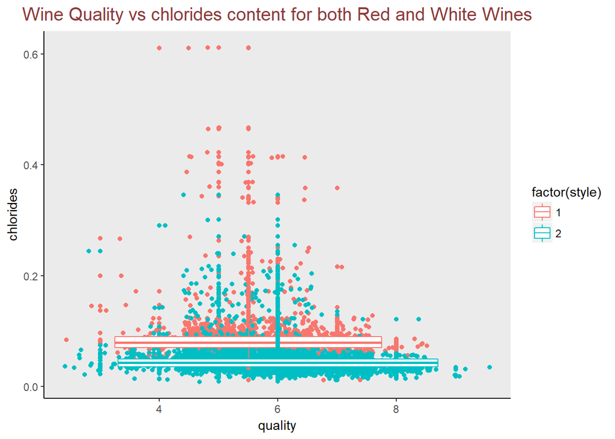

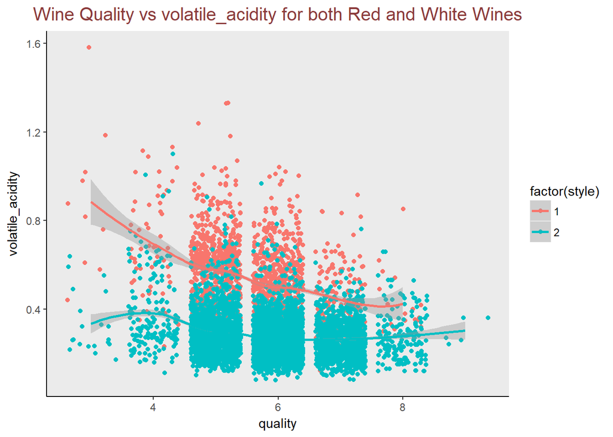

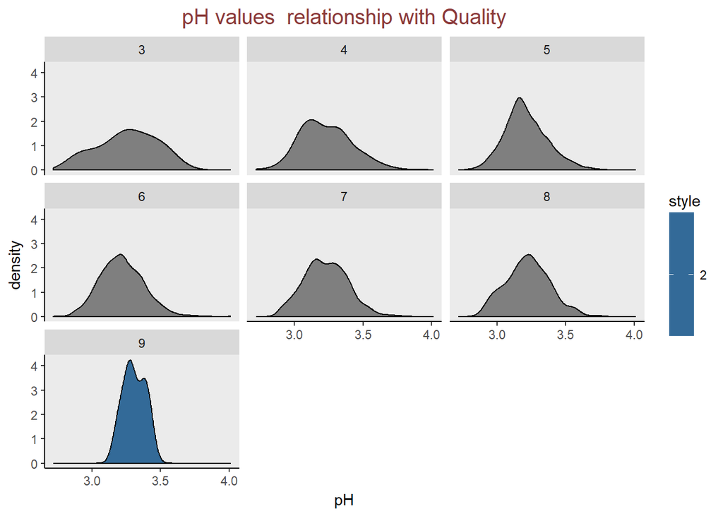

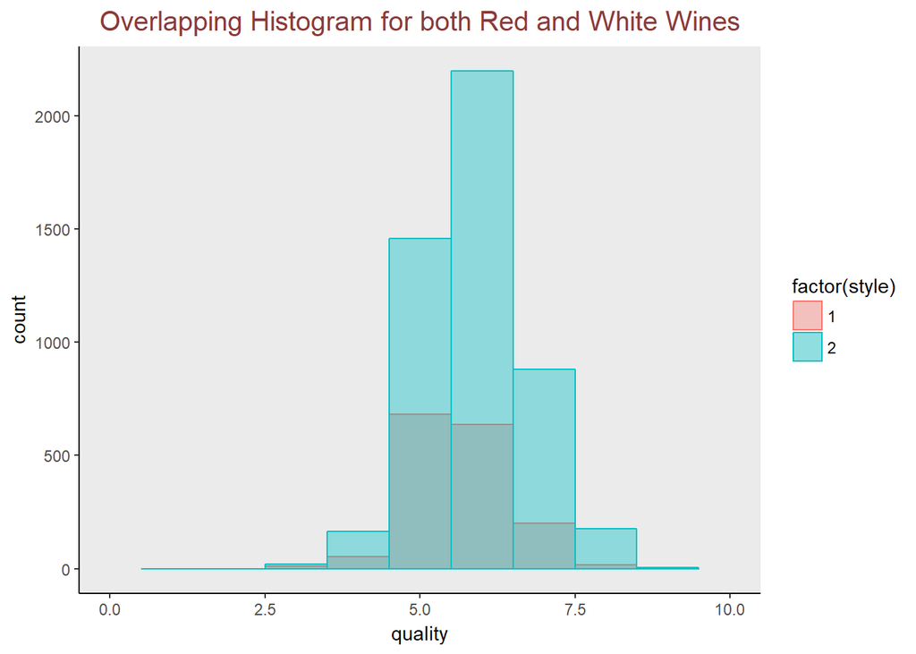

## Classification: red or white wine

Our aim is to predict with the given inputs , to which class the wine belongs. Red as “1” and white wine as “2”.

The dataset had been split into two parts in 0.7 to 0.3 ratio. Training set contains the 70% of the dataset and validation set contains the 30 % of the test set.

## Build the model using rpart (Decision Tree)

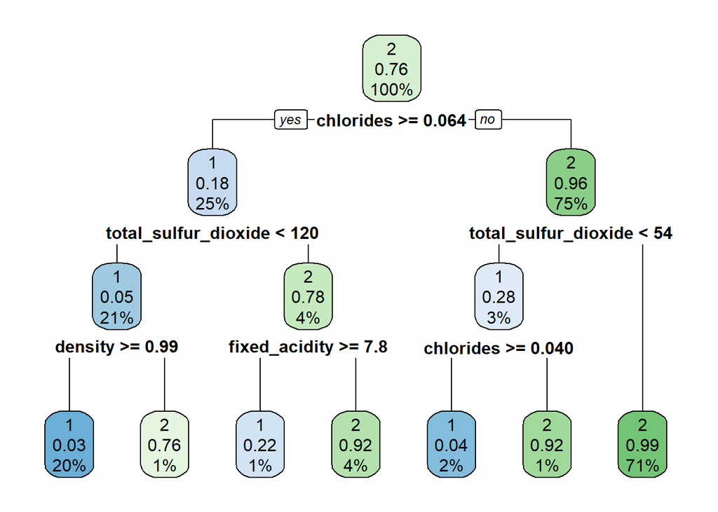

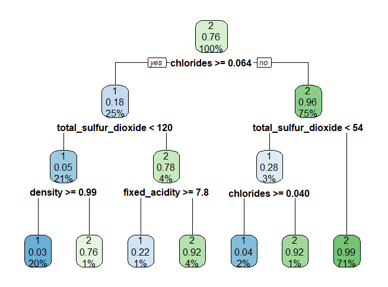

## Predict on validation set

## Confusion Matrix

```
##    class_prediction
##        1    2
##   1  481   24
##   2   16 1428
```

```
## [1] 0.9794767
```

```
## [1] 0.01108033
```

## Summary

The model accuracy is 0.97 or 97.94%. which is pretty good. But this is done on validation data set not on the unseen data set.

Due to time constrain, not much analysis has been done on the actual key factors which influence the wine quality in significant manner. As we all know the top contributing factor for the quality of wine is `Climate and Weather`, `Temperature`, `Soil` and `Sunlight`. It is correctly mentioned that wine is prepared not in wine lab but in vineyard.

### Key Findings

Top Contributing factors which has significant correlation with quality (negative or positive) are `"Alcohol"`,`"density"`,`"chlorides"` and `"volatile_acidity"`.

Careful manipulaiton in the content of these influencing variables in wine can actually influnce the quality of the wine significantly.

In other words, how actual contributing factors like `Climate and Weather`, `Temperature`, `Soil` and `Sunlight`determines the influencing variable for quality of wine will definitely help.

Here the best case scenario is to predict the class of the wine (Red or White), given the inputs with tree ML techniques, which will definitely save the time and effort to check them manually.

The model can also be built on the quality to predict its quality based on neural networks. Since that needs more computational time for both model bulding and compuation, has been kept away from the scope of this study.